# Gage R&R Study

[figure not shown]

## Declaration

**Student Name:** Rebecca Lambe Fagan

**Student Number:** D00245534

**Programme:** Mechanical Engineering Stage: Yr 4 Sem 8

**Module:** Innovation Management

**Due Date:** 10/03/2025

**Lecturer’s Name:** Rauri McCool

**Assignment No. and/or Description/Topic:** Gage R&R

**I declare that:**

- This work is entirely my own, and no part of it has been copied from any other person’s words or ideas, except as specifically acknowledged through the use of inverted commas and in-text references;
- No part of this assignment has been written for me by any other person except where such collaboration has been authorised by the lecturer concerned;
- I understand that I am bound by DkIT Academic Integrity Policy. I understand that I may be penalised if I have violated the policy in any way;
- This assignment has not been submitted for any other module at DkIT or any other institution, unless authorised by the relevant Lecturer(s);
- I have read and abided by all of the requirements set down for this assignment.

**SIGNATURE:** Rebecca Lambe Fagan

**DATE:** 09/03/2025

## Gage R&R Brief

### Procedure 2 (type-2 study)

**Repeatability and reproducibility (gage R&R) with operator influence.**

Procedure Reference: BOSCH (2020).

**Description of the Procedure**

A type-2 study is done using at least 10 (n ≥ 10) repeatably measurable and randomly selected serial parts as measuring objects. The characteristic values of these parts should preferably lie within the tolerance range. All factors should take effect that also will take effect during operation of the measuring system in series production.

The selected serial parts are measured in random order by at least three (k ≥ 3) operators in at least two (r ≥ 2) measurement series under repeatability conditions (e. g. at the test points defined in the test plan, see also chapter “Definition of terms”).

### Objective

Verification of the capability of a measurement process (as a test process for a particular characteristic) in terms of its variation behaviour using measurements of serial parts. Requirements

Before using this procedure, it should be checked whether operator influence on the measurement results has to be expected.

For example, operator influence has to be expected if

- the measurement is done manually (e. g. measurements with a vernier calliper),
- the measurement procedure is not done automatically (e. g. as CNC program),
- the analysis of raw data is influenced by the operator (e. g. determination of validity ranges of a measured contour profile),
- a clamping device is not present which ensures placement of the measuring objects in an unambiguously reproducible position,
- a clamping device is present but the clamping forces are dependent on the force that the operator exerts to operate the clamping device.

A clear definition that is generally applicable to all practical situations is not possible. A decision must generally be made for the individual situation.

**Task:** 3 students will each measure 10 parts (each repeated twice) and conduct a Gage R&R study in R. Product details are given on the final page.

**Aim: To determine if a measurement system can generate accurate data, and if the accuracy is adequate to achieve your objectives.**

**Requirement: Generate a web-page based report which will be used for training purposes for other quality control and shopfloor staff. The webpage will be expected to be followed by nontechnical staff.**

## Theory

### Measurement.

Inaccurate measurements can have detrimental effects across various industries.

Poor measurement techniques in manufacturing can result in the creation of defective products, which increases waste, and customer dissatisfaction. Poor measuring systems and other aspects of poor quality management can result in large financial losses as well as damage to a company’s reputation.

Investing in precise measurement systems is economically beneficial.

It is known that precise measurements are essential for efficient resource allocation and decision-making. On the other hand, waste, modifications, and inefficiencies brought on by inaccurate measurements may result in higher expenses. Therefore, sustaining profitability and competitiveness requires the implementation of strong measurement standards and procedures.

Various measurement instruments are utilized across industries to ensure product quality and process efficiency.

**Dimensional Measurement Instruments:**

- Calipers
- Micrometers
- Coordinate Measuring Machines (CMMs)

**Force and Pressure Instruments:**

- Load Cells
- Pressure Gauges

**Temperature Instruments:**

- Thermometers
- Thermocouples
- Infrared Sensors

**Mass and Weight Instruments:**

- Balances
- Scales

**Electrical Instruments:**

- Multimeters
- Oscilloscopes

For these devices to be accurate and long-lasting, proper maintenance is needed.

**Regular Calibration:** To ensure accuracy, instruments should be calibrated on a regular basis. Calibration is required to verify the performance of a measurement system,.

**Environmental Control:** Since variations in temperature and humidity may affect measurement accuracy, it is essential to maintain constant environmental conditions.

**Routine Cleaning and Storage:** Keeping instruments clean and storing them properly prevents damage and ensures consistent performance.

**Operator Training:** By ensuring that staff members obtain sufficient training in the usage and upkeep of instruments, user-induced errors are reduced.

**Documentation:** Monitoring instrument performance and spotting possible problems is made easier by maintaining full records of calibration, maintenance, and usage history.

### Measurement System Analysis (MSA) and Gage R&R.

Measurement System Analysis (MSA) is an in-depth assessment of a measurement process to ensure its accuracy, precision, and stability. MSA is a mathematical and experimental technique for figuring out how much variance there is in a measuring process.

Gage Repeatability and Reproducibility (Gage R&R), which evaluates the variability of the measuring system, is a crucial part of MSA. Gage R&R studies help to determine if observed differences result from measuring system inconsistencies or real variances between parts.

**Key Terms and Values Associated with Gage R&R.**

Understanding the key components of Gage R&R is essential for evaluating a measurement system’s reliability:

**Repeatability:** The variance that occurs when the same operator uses the same instrument to measure the same part more than once. When an instrument has high repeatability, it produces the same results under the same circumstances.

**Reproducibility:** The variation noticed when multiple operators measure the same component via the same measurement instrument. High reproducibility indicates that the measurement system provides consistent outcomes across different users.

**Part Variation:** the actual distinctions between the components under measurement. These variations should ideally be accurately reflected by the measurement system without causing significant variation.

**Measurement System Variation:** The combined variance from the measuring instrument, the operator, and the assessment process itself. Reducing this variance is crucial for getting precise measurements.

### Main Causes of Error in Measuring.

**Operator Errors:** These happen due to human errors like not following correct processes, lack of training, or a lack of interest These errors can be reduced by providing proper training and measurement protocols.

**Instrument Errors:** Manufacturing tolerances, inaccurate calibration, or variations between measurement and calibration situations can all lead to errors in the measuring devices themselves. To reduce these mistakes, routine calibration and maintenance are essential.

**Environmental Factors:** Changes in temperature, humidity, and other environmental factors can have an impact on the precision of measurements. These errors can be decreased by making sure that measurements are made in a consistent setting.

**Measurement Drift:** Instrument drift over time can cause gradual changes in measurement precision. To control drift, regular preventive maintenance procedures are necessary, such as cleaning, lubrication, calibration, and adjustments.

**Shift errors:** These happen when the reported measurement varies based on the location of the load on the measurement equipment due to structural or mechanical reasons. These faults can be found and fixed by doing shift tests, which include shifting the load to several locations and comparing the outcomes.

(1factory, 2024; David Collins III, 2023; Hessing, 2014; Kopper and Parry, 2013; McCalister, 2021; Penn Tool Co., Inc, 2025; Quality-one.com, 2015)

## Methodology

This study was completed by three operators and an independent data recorder.

10 random screws were measured using digital vernier calipers, each operator measured the screws twice in order, zeroing the calipers between each measurement.

The following methodology was followed.

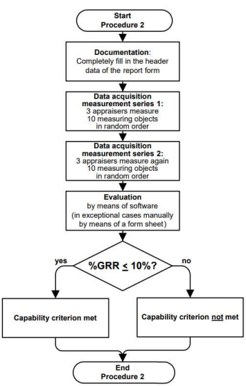

**Figure 1**

## Data

**Product description:**

- Single thread screw
- 5 mm diameter
- 50 mm length
- Carbon steel (SAE 1022)
- Application; structural timber products
- Manufactured to EN14592:2008

**Ambient Temperature:** 22 °C

Measured Lengths

| Part No. | Operator 1a | Operator 1b | Operator 2a | Operator 2b | Operator 3a | Operator 3b |
| --- | --- | --- | --- | --- | --- | --- |
| 1 | 49.276 | 49.276 | 49.276 | 49.276 | 49.276 | 49.276 |
| 2 | 49.022 | 49.022 | 49.022 | 49.022 | 49.022 | 49.022 |
| 3 | 47.752 | 47.752 | 47.498 | 47.498 | 47.752 | 47.752 |
| 4 | 49.022 | 49.276 | 49.276 | 49.022 | 49.276 | 49.276 |
| 5 | 49.276 | 49.276 | 49.276 | 49.022 | 49.276 | 49.276 |
| 6 | 47.752 | 47.752 | 47.752 | 47.752 | 47.752 | 47.752 |
| 7 | 48.768 | 48.768 | 48.768 | 48.768 | 48.768 | 48.768 |
| 8 | 49.022 | 49.022 | 49.022 | 49.022 | 49.022 | 49.022 |
| 9 | 45.974 | 45.974 | 45.720 | 45.720 | 45.720 | 45.720 |
| 10 | 49.022 | 49.022 | 49.022 | 49.022 | 49.022 | 49.022 |

*These lengths were measured twice in succession by each operator, the values were recorded by an independent Operator.

## Code Section

This is the code that is used in this study.

### Statistical Data Code

```r
PartNum = c(1,2,3,4,5,6,7,8,9,10)

Operator_1a = c(49.276, 49.022, 47.752, 49.022, 49.276, 47.752, 48.768,
                49.022, 45.974, 49.022)

Operator_1b = c(49.276, 49.022, 47.752, 49.276, 49.276, 47.752, 48.768,
                49.022, 45.974, 49.022)


Operator_2a = c(49.276, 49.022, 47.498, 49.276, 49.276, 47.752, 48.768,
                49.022, 45.72, 49.022)

Operator_2b = c(49.276, 49.022, 47.498, 49.022, 49.022, 47.752, 48.768,
                49.022, 45.72, 49.022)

Operator_3a = c(49.276, 49.022, 47.752, 49.276, 49.276, 47.752, 48.768,
                49.022, 45.72, 49.022)

Operator_3b = c(49.276, 49.022, 47.752, 49.276, 49.276, 47.752, 48.768,
                49.022, 45.72, 49.022)


Machine = c("1a", "1b", "2a", "2b", "3a", "3b")
SD = c(sd(Operator_1a), sd(Operator_1b), sd(Operator_2a), sd(Operator_2b), sd(Operator_3a), sd(Operator_3b))
Mean = c(mean(Operator_1a), mean(Operator_1b), mean(Operator_2a), mean(Operator_2b), mean(Operator_3a), mean(Operator_3b))
Min = c(min(Operator_1a), min(Operator_1b), min(Operator_2a), min(Operator_2b), min(Operator_3a), min(Operator_3b))
Max = c(max(Operator_1a), max(Operator_1b), max(Operator_2a), max(Operator_2b), max(Operator_3a), max(Operator_3b))
Count = (10)

mydata1 <- data.frame(Machine, Count, SD, Mean, Min, Max)
names(mydata1) <- c("Machine", " Count", "SD", "Mean", "Min", "Max")
knitr::kable(mydata1, align = "c", format = "html", table.attr = "border=1")
```

### Scatter Plot Code

```r
library(ggplot2)

PartNum <- c(1, 2, 3, 4, 5, 6, 7, 8, 9, 10)

Operator_1a <- c(49.276, 49.022, 47.752, 49.022, 49.276, 47.752, 48.768, 49.022, 45.974, 49.022)
Operator_1b <- c(49.276, 49.022, 47.752, 49.276, 49.276, 47.752, 48.768, 49.022, 45.974, 49.022)

Operator_2a <- c(49.276, 49.022, 47.498, 49.276, 49.276, 47.752, 48.768, 49.022, 45.72, 49.022)
Operator_2b <- c(49.276, 49.022, 47.498, 49.022, 49.022, 47.752, 48.768, 49.022, 45.72, 49.022)

Operator_3a <- c(49.276, 49.022, 47.752, 49.276, 49.276, 47.752, 48.768, 49.022, 45.72, 49.022)
Operator_3b <- c(49.276, 49.022, 47.752, 49.276, 49.276, 47.752, 48.768, 49.022, 45.72, 49.022)

mydata <- data.frame(
  PartNum = rep(1:10, times = 6),  # Repeat part numbers for each operator
  Operator = rep(c("Operator_1a", "Operator_1b", "Operator_2a",
                   "Operator_2b", "Operator_3a", "Operator_3b"), each = 10),
  Lengths = c(Operator_1a, Operator_1b, Operator_2a,
              Operator_2b, Operator_3a, Operator_3b))

mydata$Operator <- factor(mydata$Operator,
                          levels = c("Operator_1a", "Operator_1b",
                                     "Operator_2a", "Operator_2b",
                                     "Operator_3a", "Operator_3b"))


ggplot(mydata, aes(x = PartNum, y = Lengths, color = Operator, shape = Operator)) +
  geom_point(size = 3, alpha = 0.8) +
  labs(title = "Scatter Plot of Operator Measurements",
       x = "Part Number", y = "Length (mm)") + theme_minimal() +
  theme(legend.position = "bottom")
```

### Box Plot Code

```r
library(ggplot2)
library(dplyr)

df <- data.frame(
  Operator = rep(c("Operator 1", "Operator 2", "Operator 3"), each = 20),
  Measurement = c(Operator_1a, Operator_1b, Operator_2a, Operator_2b, Operator_3a, Operator_3b))

ggplot(df, aes(x = Operator, y = Measurement, fill = Operator)) +
  geom_boxplot(alpha = 0.7) + theme_minimal() +
  labs(title = "Measurement Variability Across Operators",
       x = "Operator", y = "Length (mm)") +
  theme(legend.position = "none")
```

### t-Distribution Code

```r
curve(dt(x, df = 5), from = -4, to = 4, col = "red", lwd = 2, ylim = c(0, 0.4),
      xlab = "t-value", ylab = "Density", main = "Comparison of t-Distributions")
curve(dt(x, df = 10), from = -4, to = 4, col = "blue", lwd = 2, add = TRUE)
curve(dt(x, df = 30), from = -4, to = 4, col = "green", lwd = 2, add = TRUE)
curve(dnorm(x), from = -4, to = 4, col = "black", lwd = 2, lty = 2, add = TRUE) # Normal distribution

legend("topright", legend = c("df = 5", "df = 10", "df = 30", "Normal (df → ∞)"),
       col = c("red", "blue", "green", "black"), lwd = 2, lty = c(1, 1, 1, 2))
```

```r
df_values <- c(5, 10, 30)
alpha <- 0.05
x_range <- seq(-4, 4, length = 100)

plot(x_range, dt(x_range, df_values[1]), type = "l", lwd = 2, col = "red",
     xlab = "t-value", ylab = "Density", main = "t-Distributions with Critical Regions",
     ylim = c(0, 0.45))

lines(x_range, dt(x_range, df_values[2]), col = "blue", lwd = 2)
lines(x_range, dt(x_range, df_values[3]), col = "green", lwd = 2)
lines(x_range, dnorm(x_range), col = "black", lwd = 2, lty = 2)

for (df in df_values) {critical_t <- qt(1 - alpha/2, df)

left <- seq(-4, -critical_t, length.out = 100)
polygon(c(left, rev(left)), c(dt(left, df), rep(0, 100)),
        col = adjustcolor("coral", alpha.f = 0.5), border = NA)

right <- seq(critical_t, 4, length.out = 100)
polygon(c(right, rev(right)), c(dt(right, df), rep(0, 100)),
        col = adjustcolor("coral", alpha.f = 0.5), border = NA)

abline(v = c(-critical_t, critical_t), lty = 2)}

legend("topright", legend = c("df = 5", "df = 10", "df = 30", "Normal"),
       col = c("red", "blue", "green", "black"), lwd = 2, lty = c(1, 1, 1, 2))
```

### ANOVA Testing Code

```r
library(dplyr)
library(kableExtra)

PartNum <- rep(1:10, times = 6)

Operator_1a <- c(49.276, 49.022, 47.752, 49.022, 49.276, 47.752, 48.768,
                 49.022, 45.974, 49.022)
Operator_1b <- c(49.276, 49.022, 47.752, 49.276, 49.276, 47.752, 48.768,
                 49.022, 45.974, 49.022)

Operator_2a <- c(49.276, 49.022, 47.498, 49.276, 49.276, 47.752, 48.768,
                 49.022, 45.72, 49.022)
Operator_2b <- c(49.276, 49.022, 47.498, 49.022, 49.022, 47.752, 48.768,
                 49.022, 45.72, 49.022)

Operator_3a <- c(49.276, 49.022, 47.752, 49.276, 49.276, 47.752, 48.768,
                 49.022, 45.72, 49.022)
Operator_3b <- c(49.276, 49.022, 47.752, 49.276, 49.276, 47.752, 48.768,
                 49.022, 45.72, 49.022)

Lengths <- c(Operator_1a, Operator_1b, Operator_2a, Operator_2b, Operator_3a, Operator_3b)

Operator <- factor(rep(c("Operator_1a", "Operator_1b", "Operator_2a",
                         "Operator_2b", "Operator_3a", "Operator_3b"),
                       each = 10))

mydata <- data.frame(PartNum, Operator, Lengths)

res.aov <- aov(Lengths ~ Operator, data = mydata)

anova <- summary(res.aov)[[1]]
anova_table <- data.frame(Df = anova[,"Df"],
                          SumSQ = anova[,"Sum Sq"],
                          MeanSQ = anova[,"Mean Sq"],
                          Fvalue = anova[,"F value"],
                          PrF = anova[,"Pr(>F)"])

tukey <- TukeyHSD(res.aov)
tukey_table <- as.data.frame(tukey$Operator)

tukey_table <- cbind(tukey_table, row.names(tukey_table))
names(tukey_table) <- c("Difference", "Lower", "Upper", "p adj", "Comparison")

pairwise <- pairwise.t.test(mydata$Lengths, mydata$Operator,
                            p.adjust.method = "BH")
pairwise_table <- as.data.frame(pairwise$p.value)


kable(anova_table, caption = "ANOVA Results", align = "c",
      format = "html", table.attr = "border=1") %>%
  kableExtra::kable_styling(position = "center")

kable(tukey_table, caption = "Tukey HSD Test Results", align = "c",
      format = "html", table.attr = "border=1") %>%
  kableExtra::kable_styling(position = "center")

kable(pairwise_table, caption = "Pairwise t-Test Results", align = "c",
      format = "html", table.attr = "border=1") %>%
  kableExtra::kable_styling(position = "center")

plot(res.aov, 1)
```

```r
plot(res.aov, 2)
```

### Gage R&R

```r
Operator<- factor(rep(1:3, each = 20))

Part<- factor(rep(rep(1:10, each = 2), 3))


Length<-c(49.276, 49.276, 49.022, 49.022, 47.752, 47.752, 49.022, 49.276,
            49.276, 49.276, 47.752, 47.752, 48.768, 48.768, 49.022, 49.022,
            45.974, 45.974, 49.022, 49.022,

            ##########################

            49.276, 49.276, 49.022, 49.022, 47.498, 47.498, 49.276, 49.022,
            49.276, 49.022, 47.752, 47.752, 48.768, 48.768, 49.022, 49.022,
            45.72, 45.72, 49.022, 49.022,

            ##########################

            49.276, 49.276, 49.022, 49.022, 47.752, 47.752, 49.276, 49.276,
            49.276, 49.276, 47.752, 47.752, 48.768, 48.768, 49.022, 49.022,
            45.72, 45.72, 49.022, 49.022)


Data<-data.frame(Part,Operator,Length); print(Data)


library("SixSigma")


ss.rr(var = Length, part = Part, appr = Operator, data = Data,

               main = "Six Sigma Gage R&R Study",

               sub = "",

               alphaLim = 0.05,

               errorTerm = "interaction",

               digits = 4,

               method = "crossed",

               print_plot = TRUE,

               signifstars = TRUE)
```

### Fishbone Diagram Code

```r
# Load the SixSigma package
library(SixSigma)

# Define the effect (main problem)
effect <- "Measurement Variation"

# Define the main causes (categories)
causes.gr <- c("Operator", "Environment", "Machine", "Measure Tool")

# Define individual causes under each category
causes <- vector(mode = "list", length = length(causes.gr))

# Cause 1: Operators (with two tests per operator: 'a' and 'b')
causes[1] <- list(c("Operator_1", "Operator_2", "Operator_3"))

# Cause 2: Environment (Test conditions: 'a' and 'b')
causes[2] <- list(c("Test_a", "Test_b"))

# Cause 3: Tools (example: measurement tools used)
causes[3] <- list(c("Digital Vernier Calipers"))

# Cause 4: Design (measurement design, test structure)
causes[4] <- list(c("Machine_A", "Machine_B"))


par(mar = c(5, 5, 5, 5), xpd = TRUE)

# Generate the Fishbone diagram
ss.ceDiag(effect, causes.gr, causes, sub = "Measurement Variation - Operator Measurement")
```

## Results

### **Statistical Data Results**

| Machine | Count | SD | Mean | Min | Max |
| --- | --- | --- | --- | --- | --- |
| 1a | 10 | 1.046927 | 48.4886 | 45.974 | 49.276 |
| 1b | 10 | 1.064243 | 48.5140 | 45.974 | 49.276 |
| 2a | 10 | 1.153457 | 48.4632 | 45.720 | 49.276 |
| 2b | 10 | 1.118113 | 48.4124 | 45.720 | 49.276 |
| 3a | 10 | 1.132446 | 48.4886 | 45.720 | 49.276 |
| 3b | 10 | 1.132446 | 48.4886 | 45.720 | 49.276 |

**~~~**

These statistics shows that there are variations in the measurements taken by the three operators. The mean values for each operator are relatively close, meaning that there is no significant differences in measurement. However, the standard deviations show that there is slight differences in variability with some operators being more consistent than others. The min and max values further back this up as they show a wider range of values for some operators.

### **Scatter Plot Results**

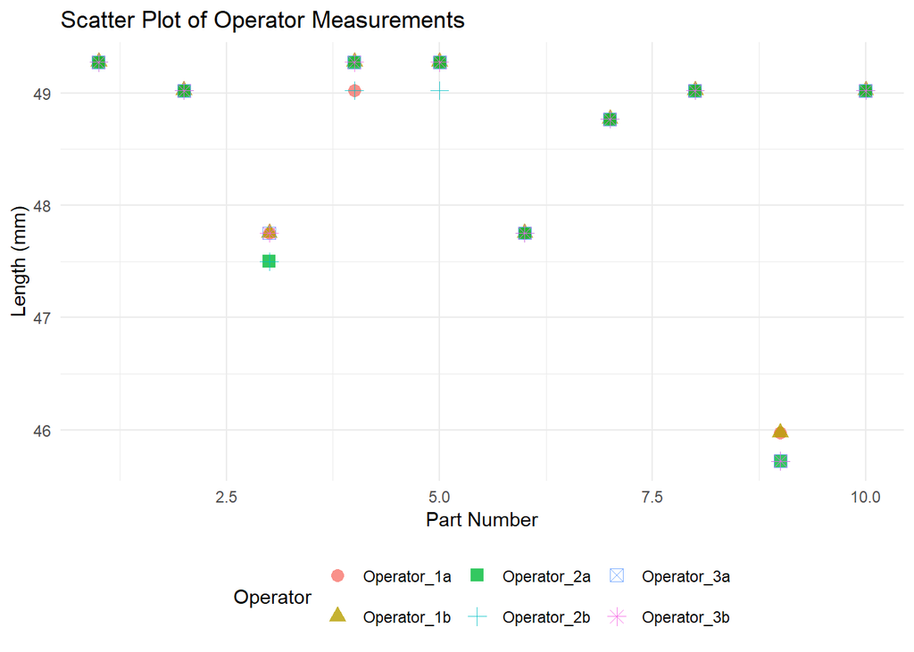

**~~~**

The Scatter Plot provides a visual image of the trends across the 10 screws and the operator measurements. The point distribution indicates that there are minor differences despite the results following a similar pattern. The points in dense clusters show the consistency among the operators, while the more widely dispersed points show areas of inconsistent measurement, or production issues.

### **Box Plot Results**

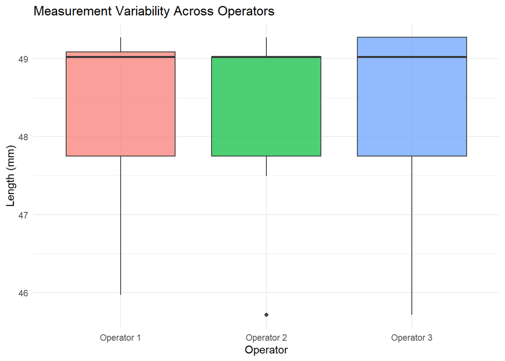

**~~~**

The Box Plot gives another visual representation of the variability of measurement. The smaller boxes of Operator 1 and 2 show more consistency than that of operator 3, this again highlights the differences in each operators measurement of the screws. Outliers here could point toward operator measurement errors, calibration errors, or machine production errors.

### **t-Distribution Results**

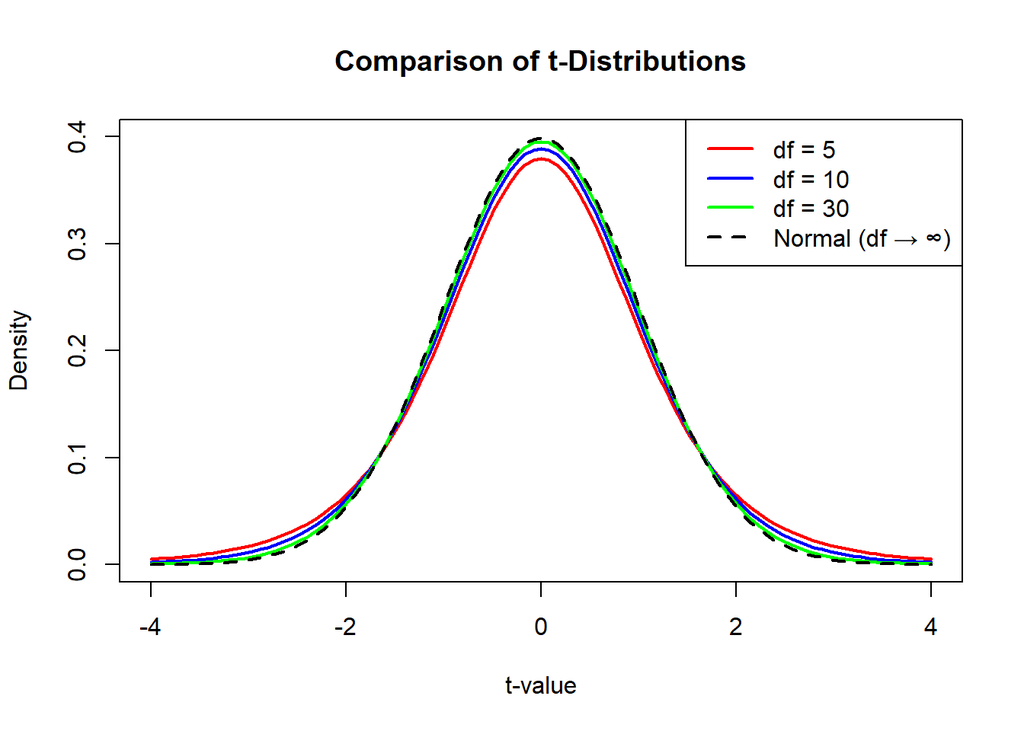

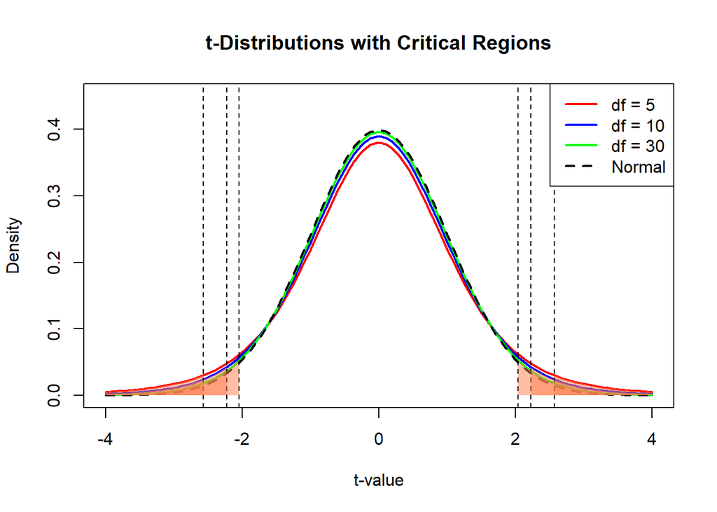

**~~~**

The t-Distribution representations demonstrate how degrees of freedom (df) effect the distribution’s form and behaviour. Heavy tails result from lower df values, like 5, which indicates that the distribution has more variability and is prone to extreme values. The t-Distribution gradually becomes closer to the normal distribution as the df rises from 5 to 10 and 30.

Since bigger critical t-values are needed to achieve significance for smaller sample sizes, this has serious implications for hypothesis testing. Higher df values decrease the rejection region, which makes the testing more accurate and stable. This can be seen in the second plot where the rejection zone is highlighted.

### **ANOVA Testing Results**

ANOVA Results

| Df | SumSQ | MeanSQ | Fvalue | PrF |
| --- | --- | --- | --- | --- |
| 5 | 0.0612902 | 0.012258 | 0.0099738 | 0.999969 |
| 54 | 66.3676092 | 1.229030 | NA | NA |

Tukey HSD Test Results

|  | Difference | Lower | Upper | p adj | Comparison |
| --- | --- | --- | --- | --- | --- |
| Operator_1b-Operator_1a | 0.0254 | -1.439396 | 1.490196 | 0.9999999 | Operator_1b-Operator_1a |
| Operator_2a-Operator_1a | -0.0254 | -1.490196 | 1.439396 | 0.9999999 | Operator_2a-Operator_1a |
| Operator_2b-Operator_1a | -0.0762 | -1.540996 | 1.388596 | 0.9999873 | Operator_2b-Operator_1a |
| Operator_3a-Operator_1a | 0.0000 | -1.464796 | 1.464796 | 1.0000000 | Operator_3a-Operator_1a |
| Operator_3b-Operator_1a | 0.0000 | -1.464796 | 1.464796 | 1.0000000 | Operator_3b-Operator_1a |
| Operator_2a-Operator_1b | -0.0508 | -1.515596 | 1.413996 | 0.9999983 | Operator_2a-Operator_1b |
| Operator_2b-Operator_1b | -0.1016 | -1.566396 | 1.363196 | 0.9999472 | Operator_2b-Operator_1b |
| Operator_3a-Operator_1b | -0.0254 | -1.490196 | 1.439396 | 0.9999999 | Operator_3a-Operator_1b |
| Operator_3b-Operator_1b | -0.0254 | -1.490196 | 1.439396 | 0.9999999 | Operator_3b-Operator_1b |
| Operator_2b-Operator_2a | -0.0508 | -1.515596 | 1.413996 | 0.9999983 | Operator_2b-Operator_2a |
| Operator_3a-Operator_2a | 0.0254 | -1.439396 | 1.490196 | 0.9999999 | Operator_3a-Operator_2a |
| Operator_3b-Operator_2a | 0.0254 | -1.439396 | 1.490196 | 0.9999999 | Operator_3b-Operator_2a |
| Operator_3a-Operator_2b | 0.0762 | -1.388596 | 1.540996 | 0.9999873 | Operator_3a-Operator_2b |
| Operator_3b-Operator_2b | 0.0762 | -1.388596 | 1.540996 | 0.9999873 | Operator_3b-Operator_2b |
| Operator_3b-Operator_3a | 0.0000 | -1.464796 | 1.464796 | 1.0000000 | Operator_3b-Operator_3a |

Pairwise t-Test Results

|  | Operator_1a | Operator_1b | Operator_2a | Operator_2b | Operator_3a |
| --- | --- | --- | --- | --- | --- |
| Operator_1b | 1 | NA | NA | NA | NA |
| Operator_2a | 1 | 1 | NA | NA | NA |
| Operator_2b | 1 | 1 | 1 | NA | NA |
| Operator_3a | 1 | 1 | 1 | 1 | NA |
| Operator_3b | 1 | 1 | 1 | 1 | 1 |

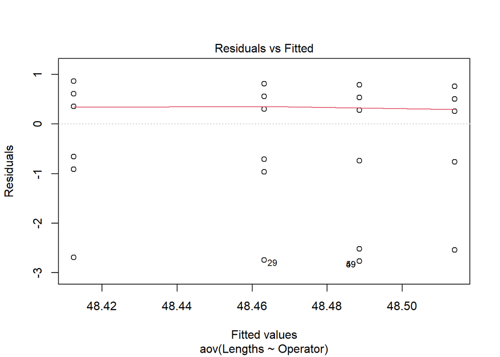

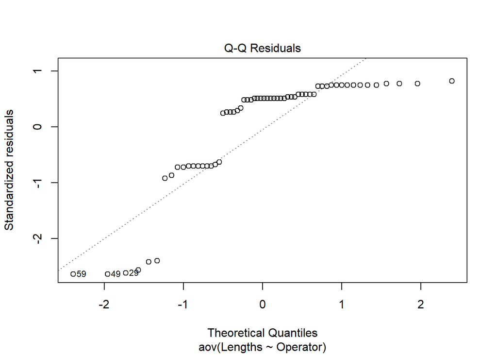

**~~~**

The Tukey HSD test uses pairwise comparisons to determine which operator is showing inconsistencies to help pinpoint where the differences are coming from. If the adjusted P-Value for any pair is below 0.05, those operators have significantly different mean values.

The Pairwise Test provides more direct comparisons to support the conclusions made from the two previous tests. Inconsistent findings from different operators may be from measurement errors, calibration or machine settings.

Diagnostic plots from the ANOVA analysis evaluate the validity of the assumptions.

The residual vs. fitted plot is a scatter plot of the residuals on the vertical axis and the fitted values on the horizontal axis. A random distribution around the zero line is expected on the Residual vs Fitted Plot, any noticeable pattern indicates the variation of the results which can affect the validity of th ANOVA Test.

The Q-Q plot (quantile-quantile plot) plots the observed data points (residuals) against the expected normal distribution. Any stray from the reference line suggests irregularities, the Q-Q Plot determines whether residuals have a normal distribution or not.

### **Gage R&R Results**

[output not shown]

[output cut: 46 more lines]

```
## Complete model (with interaction):
##
##               Df Sum Sq Mean Sq F value  Pr(>F)
## Part           9  66.12   7.346 778.342 < 2e-16 ***
## Operator       2   0.05   0.023   2.392 0.11985
## Part:Operator 18   0.17   0.009   2.926 0.00453 **
## Repeatability 30   0.10   0.003
## Total         59  66.43
## ---
## Signif. codes:  0 '***' 0.001 '**' 0.01 '*' 0.05 '.' 0.1 ' ' 1
##
## alpha for removing interaction: 0.05
##
## Gage R&R
##
##                        VarComp %Contrib
## Total Gage R&R    0.0069892333     0.57
##   Repeatability   0.0032258000     0.26
##   Reproducibility 0.0037634333     0.31
##     Operator      0.0006571074     0.05
## Part:Operator     0.0031063259     0.25
## Part-To-Part      1.2228171481    99.43
## Total Variation   1.2298063815   100.00
##
##                       StdDev  StudyVar %StudyVar
## Total Gage R&R    0.08360163 0.5016098      7.54
##   Repeatability   0.05679613 0.3407768      5.12
##   Reproducibility 0.06134683 0.3680810      5.53
##     Operator      0.02563411 0.1538046      2.31
## Part:Operator     0.05573442 0.3344065      5.03
## Part-To-Part      1.10581063 6.6348638     99.72
## Total Variation   1.10896636 6.6537981    100.00
##
## Number of Distinct Categories = 18
```

[figure not shown]

**~~~**

The Gage R&R (Six Sigma) Study assesses the variation in measurements due to both the measuring system and the operators. The purpose of this study is to assess the measurement system’s capacity to provide accurate and consistent findings when the same samples are being measured by different operators.

The Measurement by Part plot indicates whether variances are due to measurement irregularities or real part differences. Part-to-part variance indicates a measurement uniformity issue if it exceeds acceptable limits. The Measurement by Operator plot, which displays differences in mean measurements across multiple operators, adds additional support to this. Reproducibility issues get worse if particular operators often measure higher or lower than others, which suggests that there is a pattern in measuring. The Part-Operator Interaction plot also evaluates the consistency of operator measurement patterns across several parts. Inconsistencies in data collecting may result from operators measuring certain parts differently than others.

These findings are critical in determining whether the verniers need recalibration or if operators need training.

### **Fishbone Diagram**

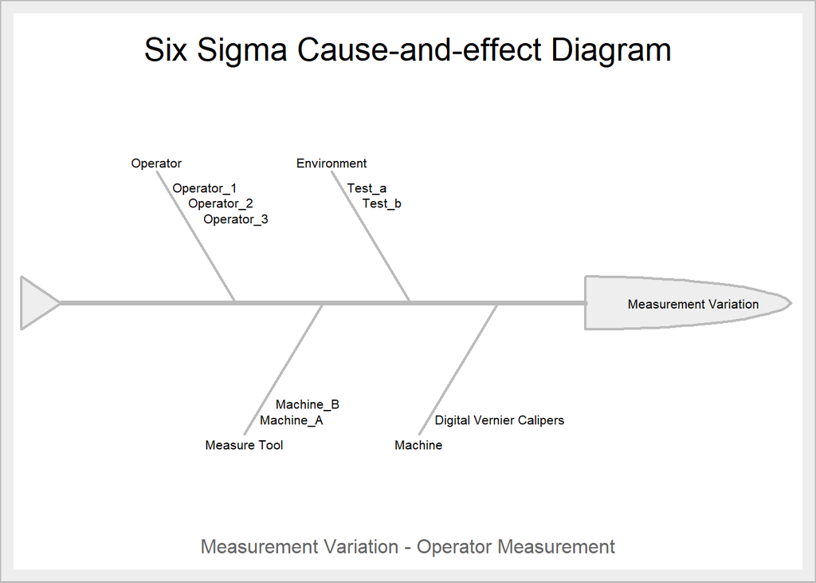

**~~~**

Errors may be introduced by different operators’ fatigue different measurement methods, or varied levels of experience.

Examining the surrounding circumstances is also important since, especially with precision-based evaluations, elements like noise and external distractions can have an impact on readings.

Inconsistencies between various measurement periods may be explained by variance introduced by the machines if they are not properly calibrated or maintained.

## Conclusion

- **Operator Training:** Put an emphasis on standard measuring practices, minimise operator-induced variability, and enhance measurement consistency through focused training programs.
- **Machine Calibration:** To avoid mechanical mistakes that might alter readings, make sure that machines are routinely calibrated and properly maintained.
- **Tool Calibration:** Verniers and other measuring devices should be regularly inspected and calibrated to make sure they are not causing any errors that have been noticed.
- **Environmental Control:** Manage surrounding elements that might affect precise readings, such as noise and distractions.

## References

1factory (2024). A Guide to Gage R&R (Repeatability & Reproducibility) | 1factory. [online] 1factory.com. Available at: https://www.1factory.com/quality-academy/guide-gage-r-and-r.html.

Green, E. (2017). add vertical space above and below figures/code chunks. [online] Stack Overflow. Available at: https://stackoverflow.com/questions/43379224/add-vertical-space-above-and-below-figures-code-chunks.

Hessing, T. (2014). Gage Repeatability and Reproducibility (R&R) | Six Sigma Study Guide. [online] Six Sigma Study Guide. Available at: https://sixsigmastudyguide.com/repeatability-and-reproducibility-rr/.

JMP Statistical Discovery (2023). The t-Test. [online] www.jmp.com. Available at: https://www.jmp.com/en_ch/statistics-knowledge-portal/t-test.html.

Kopper, S. and Parry, K. (2013). Introduction to measurement and indicators. [online] The Abdul Latif Jameel Poverty Action Lab (J-PAL). Available at: https://www.povertyactionlab.org/resource/introduction-measurement-and-indicators.

McCalister, J. (2021). Common Causes of Errors in Measurement. [online] Premier Scales & Systems. Available at: https://premierscales.com/common-causes-of-measurement-errors/.

Paredes, R. (2024). Ishikawa Diagram: Guide on How to Use It. [online] SafetyCulture. Available at: https://safetyculture.com/topics/ishikawa-diagram/.

Penn Tool Co., Inc. (2025). Penn Tool Co. [online] Available at: https://www.penntoolco.com/blog/essential-quality-control-measuring-devices/?srsltid=AfmBOooYhfcL07tY04BKWc-uFPE0F92D-xT7OL3XpPVJsDgOY_x_n2cx.

Quality-one.com. (2015a). Gage R&R | Gage Repeatability & Reproducibility | Quality-One. [online] Available at: https://quality-one.com/grr/.

Quality-one.com. (2015b). MSA | Measurement System Analysis | Quality-One. [online] Available at: https://quality-one.com/msa/.

Qualtrics (2020). An Introduction to T-test Theory for Surveys | Qualtrics. [online] Qualtrics. Available at: https://www.qualtrics.com/en-gb/experience-management/research/t-test/.

R-bloggers. (2013). Shading regions under a curve | R-bloggers. [online] Available at: https://www.r-bloggers.com/2013/01/shading-regions-under-a-curve/.

support.minitab.com. (2023). Interpret the key results for Crossed Gage R&R Study. [online] Available at: https://support.minitab.com/en-us/minitab/help-and-how-to/quality-and-process-improvement/measurement-system-analysis/how-to/gage-study/crossed-gage-r-r-study/interpret-the-results/key-results/.